# Chapter 8 Lab

## 8.3.4 - Boosting

Use the `gbm` packagge to fit boosted regression trees to the `Boston` data set.

```r
library(gbm)
library(MASS)
```

|  | var | rel.inf |
| --- | --- | --- |
| lstat | lstat | 47.36239709 |
| rm | rm | 17.99684078 |
| dis | dis | 8.94376486 |
| crim | crim | 5.93252840 |
| nox | nox | 4.90776386 |
| black | black | 4.07173453 |
| age | age | 3.31772508 |
| ptratio | ptratio | 2.89635717 |
| tax | tax | 1.80569162 |
| chas | chas | 1.19880827 |

[output cut: 3 more lines]

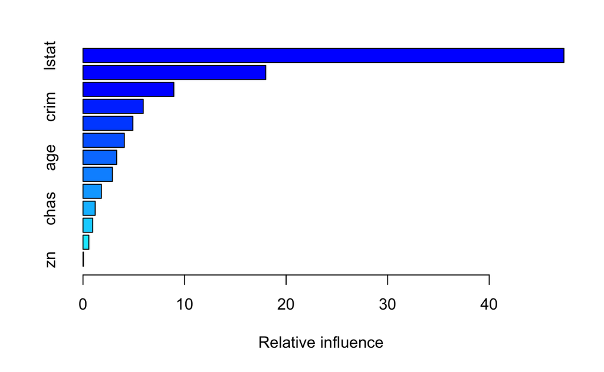

```r
set.seed(647)

train = sample(1:nrow(Boston), nrow(Boston) / 2)

boston.test = Boston[-train, "medv"]

boost.boston = gbm(
  medv ~ .,
  data = Boston[train, ],
  distribution = "gaussian",
  n.trees = 5000,
  interaction.depth = 4
)

summary(boost.boston)
```

`lstat` and `rm` are the most important varaibles.

Let’s produce the *partial dependence plots* for these varaibles, which illustrate the **marginal effect of the selected variables on the response after integrating out the other variables**.

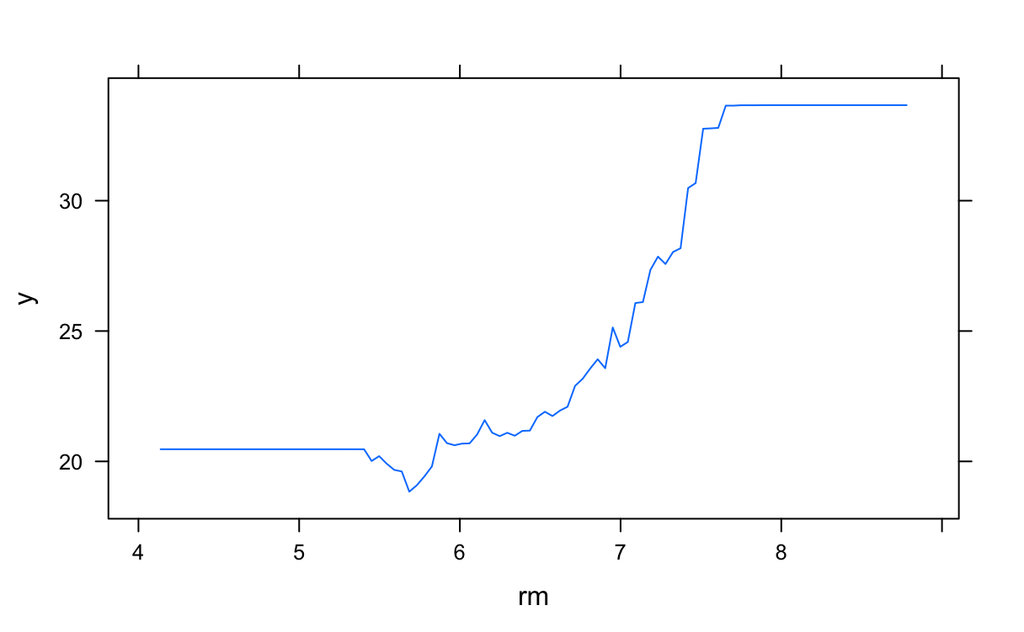

```r
par(mfrow=c(1,2))

plot(boost.boston, i = 'rm')
```

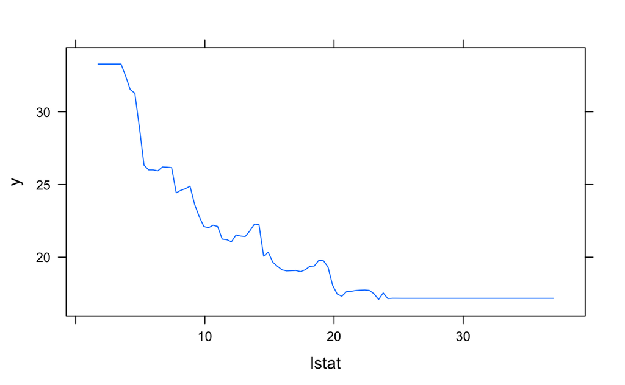

```r
plot(boost.boston, i = 'lstat')
```

Predict on the test set.

```r
yhat.boost = predict(boost.boston, newdata = Boston[-train,], n.trees = 5000)

mean((yhat.boost - boston.test) ^ 2)
```

```
[1] 10.19316
```

Lets try another value of shrinkage parameters $\lambda$ (default is 0.001).

```r
boost.boston = gbm(
  medv ~ .,
  data = Boston[train, ],
  distribution = "gaussian",
  n.trees = 5000,
  interaction.depth = 4,
  shrinkage = 0.2
)

yhat.boost = predict(boost.boston, newdata = Boston[-train,], n.trees = 5000)

mean((yhat.boost - boston.test) ^ 2)
```

```
[1] 12.57359
```

Slightly higher test MSE.